# Fancy: Hybrid Network Inference for Microbiome Co-Abundance Analysis

Wanxin Lai

2026-03-08

# 1 Introduction

**Fancy** infers microbial co-abundance networks using a hybrid scoring framework that combines kNN-based mutual information (MI), MRNET edge selection, and distance correlation (dCor) within a bootstrap resampling loop. Each bootstrap iteration computes an MI matrix, applies MRNET for sparse edge selection, and independently computes pairwise dCor. The final hybrid score ranks edges by combining MRNET edge frequency with dCor stability across bootstraps.

This hybrid approach captures **nonlinear** associations between MAGs, including threshold effects, competitive exclusion, and other ecological interactions that linear correlation measures miss.

```r
library(Fancy)
```

# 2 Example Data

Fancy ships with a dataset subset from a published cattle rumen metagenome study. The data contains **100 MAGs across 321 samples** with CLR-transformed abundances pre-computed on the full 2178-MAG compositional reference:

- **MAGs 1-2**: Bulleidia vs AC2028 (both Bacillota), showing threshold competitive exclusion
- **MAGs 3-4**: RUG023 (Spirochaetota) vs Cryptobacteroides (Bacteroidota), showing an L-shaped nonlinear relationship
- **MAGs 5-100**: high-quality MAGs spanning 9 phyla

```r
data(fancy_tiny_clr)
data(fancy_tiny_counts)
data(fancy_tiny_coverage)
data(fancy_tiny_taxonomy)
data(fancy_tiny_metadata)
dim(fancy_tiny_clr)    # MAGs x samples (CLR-transformed)
```

```
#> [1] 100 321
```

```r
fancy_tiny_clr[1:5, 1:5]
```

```
#>         Sample_001 Sample_002 Sample_003 Sample_004  Sample_005
#> MAG_001 -1.4452339 -0.8091287 -0.7510971  0.1360897 -1.27453076
#> MAG_002  0.6111012  0.7826824  0.9602607 -1.5487055  0.24604355
#> MAG_003 -0.7414102  1.1039286  1.6685132  3.9810748  0.04382526
#> MAG_004 -1.0266201 -1.0009358 -0.7654210 -0.7946228 -0.37945251
#> MAG_005  0.3110781  0.1937208 -0.2376735 -0.3140157 -0.06940226
```

The taxonomy spans 9 phyla:

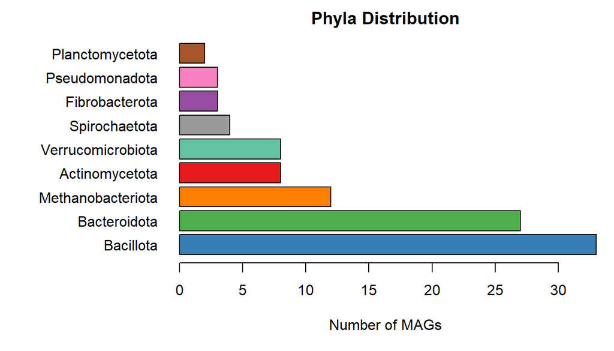

```r
phyla_counts <- sort(table(fancy_tiny_taxonomy$Phyla), decreasing = TRUE)
par(mar = c(5, 10, 2, 1))
barplot(phyla_counts, horiz = TRUE, las = 1,
        col = phyla_palette(names(phyla_counts))[names(phyla_counts)],
        xlab = "Number of MAGs", main = "Phyla Distribution")
```

## 2.1 Coverage distribution

Coverage values reflect real genome mapping fractions. Most MAGs in this subset have high coverage, as they were selected for genome quality (coverage >= 0.5 in >= 200 samples).

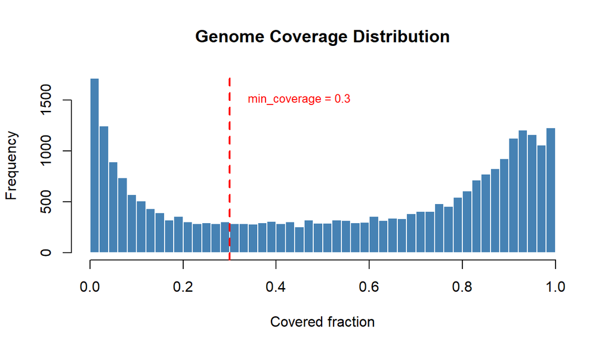

```r
cov_vals <- unlist(fancy_tiny_coverage)
hist(cov_vals, breaks = 60, main = "Genome Coverage Distribution",
     xlab = "Covered fraction", col = "steelblue", border = "white")
abline(v = 0.3, col = "red", lwd = 2, lty = 2)
text(0.32, par("usr")[4] * 0.85, "min_coverage = 0.3",
     col = "red", cex = 0.8, pos = 4)
```

```r
cat("Fraction with coverage >= 0.3:", round(mean(cov_vals >= 0.3, na.rm = TRUE), 4), "\n")
```

```
#> Fraction with coverage >= 0.3: 0.6763
```

## 2.2 Metadata

The metadata links each sample to methane emissions (CH4) and cattle breed.

```r
head(fancy_tiny_metadata)
```

```
#>       Sample       Breed   CH4
#> 1 Sample_001       Luing 17.96
#> 2 Sample_002       Luing 18.16
#> 3 Sample_003 Charolais_X 25.97
#> 4 Sample_004 Charolais_X 18.85
#> 5 Sample_005       Luing 20.93
#> 6 Sample_006 Charolais_X 12.70
```

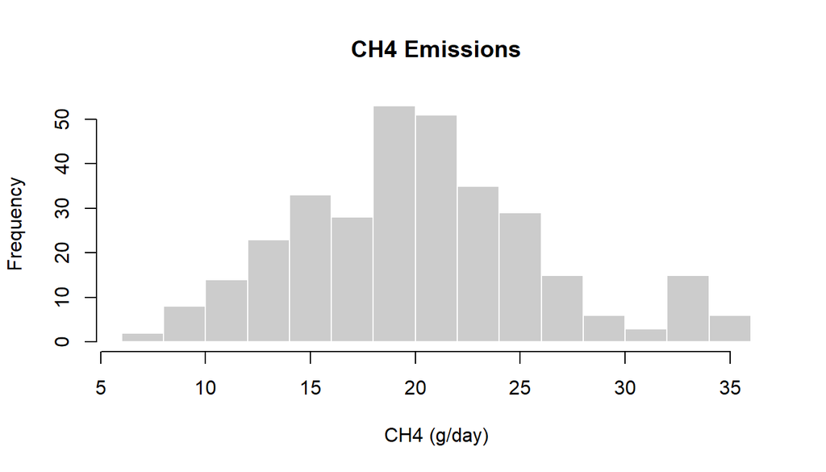

```r
hist(fancy_tiny_metadata$CH4, breaks = 15, main = "CH4 Emissions",
     xlab = "CH4 (g/day)", col = "grey80", border = "white")
```

# 3 Preparing the Network Input

The shipped CLR matrix (`fancy_tiny_clr`) was computed on the full 2178-MAG compositional reference, preserving the proper geometric mean. Network functions in Fancy expect **samples as rows, MAGs as columns**, so we transpose:

```r
net_input <- t(fancy_tiny_clr)
dim(net_input)  # samples x MAGs
```

```
#> [1] 321 100
```

```r
net_input[1:5, 1:5]
```

```
#>               MAG_001    MAG_002     MAG_003    MAG_004     MAG_005
#> Sample_001 -1.4452339  0.6111012 -0.74141025 -1.0266201  0.31107806
#> Sample_002 -0.8091287  0.7826824  1.10392858 -1.0009358  0.19372079
#> Sample_003 -0.7510971  0.9602607  1.66851318 -0.7654210 -0.23767346
#> Sample_004  0.1360897 -1.5487055  3.98107483 -0.7946228 -0.31401566
#> Sample_005 -1.2745308  0.2460435  0.04382526 -0.3794525 -0.06940226
```

**Note:** If you are working with your own raw count data, run `filter_mags()` then `clr_normalize()` before transposing. The example data ships pre-CLR to avoid recomputing CLR on a reduced MAG set, which would distort the geometric mean.

# 4 Why a Hybrid Scoring Framework?

Fancy combines two complementary approaches in a bootstrap framework:

1. **Mutual information + MRNET**: kNN-based MI captures *all* types of statistical dependencies (linear and nonlinear). MRNET then sparsifies the MI network by removing indirect edges, retaining only the most informative direct associations. The fraction of bootstrap iterations in which MRNET selects an edge gives the **EdgeFrequency**.
2. **Distance correlation (dCor)**: Computed independently in each bootstrap iteration, dCor provides a second nonlinear dependency measure. The ratio of mean dCor to its standard deviation across bootstraps gives a **Stability** score, meaning edges with consistently high dCor are more trustworthy.

The final **HybridScore** ranks edges by combining both signals. Fancy offers two scoring modes:

## 4.1 Multiplicative scoring (default)

$$\text{HybridScore} \;=\; \text{EdgeFrequency}^{\,w_1} \;\times\; \text{Stability.dcor.scaled}^{\,w_2}$$

$w_1$ controls the weight on MRNET edge frequency and $w_2$ controls the weight on dCor stability (default $w_1 = 0.3$, $w_2 = 0.7$). Edges need support from **both** components: a near-zero value in either pulls the score toward zero.

## 4.2 Additive scoring

$$\text{HybridScore} \;=\; w_1 \times \text{EdgeFrequency} \;+\; w_2 \times \text{Stability.dcor.scaled}$$

Set `score_type = "additive"` in `fancy()` to use this mode. This allows edges with strong dCor but weak MRNET frequency (or vice versa) to retain a meaningful score — useful when users want purely dCor-discovered edges to carry weight.

## 4.3 dCor rescue (multiplicative mode)

For multiplicative scoring, a `dcor_rescue_percentile` option is available (e.g. `dcor_rescue_percentile = 0.6`). Edges whose `Stability.dcor.scaled` exceeds the given percentile receive a minimum `EdgeFrequency` floor (the 30th percentile of non-zero EdgeFrequency values). This prevents MRNET from suppressing edges that dCor finds reliably — important for users who believe some associations are only detectable by dCor and not MI/MRNET.

This hybrid approach captures nonlinear ecological interactions that Pearson or Spearman correlation would miss.

# 5 Running the Pipeline

`fancy()` wraps the full pipeline: bootstrap network inference, edge scoring, and thresholding.

| Parameter | Default | Suggested | Description |
| --- | --- | --- | --- |
| `n_bootstrap` | 100 | 100 to 200 | Number of bootstrap iterations |
| `k` | 5 | 3 to 7 | kNN parameter for MI estimation |
| `find_k` | FALSE | TRUE for exploratory runs | Auto-select k via elbow method |
| `cpus` | 4 | 2 to 8 | Number of parallel workers |
| `use_mrnet` | TRUE | TRUE | Apply MRNET for sparse edge selection |
| `w1` | 0.3 | 0.2 to 0.4 | Weight for edge frequency |
| `w2` | 0.7 | 0.6 to 0.8 | Weight for dCor stability |
| `threshold_method` | “quantile” | “quantile” or “top_n” | How to threshold edges |
| `threshold_value` | 0.7 | 0.7 to 0.9 | Quantile cutoff (top 30 percent at 0.7) |

We run **100 bootstrap iterations** here for meaningful hybrid scores. We set `cpus = 6L` for parallel processing and use the default 70th percentile threshold. Because this dataset contains high-quality MAGs subset from real data (100 MAGs, 321 samples), we use **equal weights** (`w1 = w2 = 0.5`) so that MRNET edge frequency and dCor stability contribute equally to the hybrid score.

```r
result <- fancy(
  net_input,
  n_bootstrap     = 100L,
  k               = 3L,
  cpus            = 6L,
  w1              = 0.5,
  w2              = 0.5,
  threshold_method = "quantile",
  threshold_value  = 0.7,
  verbose          = TRUE
)
```

```
#> Library minet loaded.
#> Library energy loaded.
#> Library knnmi loaded.
```

# 6 Inspecting Results

The result is a list with class `"fancy"`:

```r
str(result, max.level = 1)
```

```
#> List of 6
#>  $ edges               : tibble [687 × 8] (S3: tbl_df/tbl/data.frame)
#>  $ all_edges           : tibble [2,288 × 8] (S3: tbl_df/tbl/data.frame)
#>  $ all_edges_unfiltered: tibble [4,950 × 8] (S3: tbl_df/tbl/data.frame)
#>  $ k                   : int 3
#>  $ n_bootstrap         : int 100
#>  $ params              :List of 11
#>  - attr(*, "class")= chr "fancy"
```

```r
cat("\nRetained edges:", nrow(result$edges), "\n")
```

```
#>
#> Retained edges: 687
```

```r
cat("Total scored edges:", nrow(result$all_edges), "\n")
```

```
#> Total scored edges: 2288
```

With 100 MAGs there are `choose(100, 2)` = 4,950 possible pairwise edges. After bootstrap filtering (minimum EdgeFrequency and dCor stability), 2288 edges are scored. The 70th percentile threshold retains 687 of these.

Top 5 edges by hybrid score:

```r
top5 <- head(result$edges[order(-result$edges$HybridScore), ], 5)
knitr::kable(as.data.frame(top5), digits = 3, row.names = FALSE)
```

| source | target | EdgeFrequency | mean.dcor | sd.dcor | Stability.dcor | Stability.dcor.scaled | HybridScore |
| --- | --- | --- | --- | --- | --- | --- | --- |
| MAG_002 | MAG_085 | 1 | 0.872 | 0.015 | 57.302 | 1 | 1 |
| MAG_002 | MAG_090 | 1 | 0.882 | 0.015 | 60.756 | 1 | 1 |
| MAG_007 | MAG_018 | 1 | 0.876 | 0.014 | 61.579 | 1 | 1 |
| MAG_007 | MAG_023 | 1 | 0.870 | 0.014 | 62.632 | 1 | 1 |
| MAG_007 | MAG_027 | 1 | 0.917 | 0.009 | 99.909 | 1 | 1 |

## 6.1 Diagnostic Table for Known Nonlinear Pairs

The `all_edges_unfiltered` component contains all 4950 pairs with their intermediate metrics, including pairs that were dropped by the hard pre-filter. This is useful for inspecting known nonlinear pairs:

```r
## Known nonlinear pairs (MAGs 1-4)
pairs <- list(c("MAG_001", "MAG_002"), c("MAG_003", "MAG_004"))
diag_rows <- lapply(pairs, function(p) {
  uf <- result$all_edges_unfiltered
  idx <- which((uf$source == p[1] & uf$target == p[2]) |
               (uf$source == p[2] & uf$target == p[1]))
  if (length(idx)) as.data.frame(uf[idx[1], ])
})
diag_df <- do.call(rbind, diag_rows)
knitr::kable(
  diag_df[, c("source", "target", "EdgeFrequency", "mean.dcor", "sd.dcor",
              "Stability.dcor", "Stability.dcor.scaled", "HybridScore")],
  digits = 3, row.names = FALSE,
  caption = "Intermediate metrics for known nonlinear MAG pairs"
)
```

Table 1: Intermediate metrics for known nonlinear MAG pairs

| source | target | EdgeFrequency | mean.dcor | sd.dcor | Stability.dcor | Stability.dcor.scaled | HybridScore |
| --- | --- | --- | --- | --- | --- | --- | --- |
| MAG_001 | MAG_002 | 0.95 | 0.539 | 0.033 | 16.210 | 0.216 | 0.453 |
| MAG_003 | MAG_004 | 0.48 | 0.366 | 0.032 | 11.585 | 0.115 | 0.235 |

The table shows where each pair sits: **EdgeFrequency** (how often MRNET selected the edge across bootstraps), **mean.dcor** and **sd.dcor** (dCor mean and variability), **Stability.dcor** (mean/sd ratio), and the final **HybridScore**. If a pair has EdgeFrequency below 0.3, it was dropped from `all_edges` by the hard pre-filter but remains visible here.

# 7 Edges Across Hybrid Score Bands

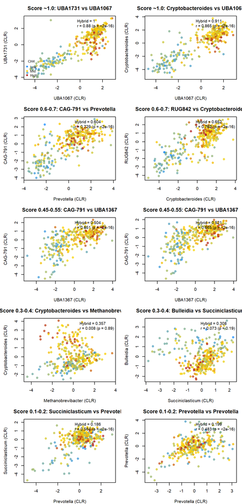

```r
all_scored <- result$all_edges[order(-result$all_edges$HybridScore), ]

## Define five score bands and sample 2 pairs from each
bands <- list(
  c(0.9, Inf),
  c(0.6, 0.7),
  c(0.45, 0.55),
  c(0.3, 0.4),
  c(0.1, 0.2)
)
band_labels <- c("~1.0", "0.6-0.7", "0.45-0.55", "0.3-0.4", "0.1-0.2")

set.seed(42)
show_pairs <- data.frame()
for (b in seq_along(bands)) {
  lo <- bands[[b]][1]
  hi <- bands[[b]][2]
  in_band <- all_scored[all_scored$HybridScore >= lo &
                        all_scored$HybridScore < hi, ]
  if (nrow(in_band) == 0) {
    ## If exact band is empty, take the 2 closest edges to midpoint
    mid <- (lo + hi) / 2
    all_scored$dist_tmp <- abs(all_scored$HybridScore - mid)
    in_band <- head(all_scored[order(all_scored$dist_tmp), ], 2)
    all_scored$dist_tmp <- NULL
  }

  ## For mid bands (0.3-0.55): prefer low sd.dcor + weak Pearson r
  ## For lowest band (0.1-0.2): prefer higher Pearson r to show that
  ## linearly correlated pairs correctly receive low hybrid scores
  if ((hi <= 0.55 && lo >= 0.3) && nrow(in_band) > 2) {
    in_band$abs_r <- vapply(seq_len(nrow(in_band)), function(j) {
      abs(cor(net_input[, in_band$source[j]],
              net_input[, in_band$target[j]]))
    }, numeric(1))
    low_r <- in_band[in_band$abs_r < 0.4, ]
    if (nrow(low_r) >= 2) {
      low_r <- low_r[order(low_r$sd.dcor), ]
      picked <- head(low_r, 2)
    } else {
      in_band <- in_band[order(in_band$sd.dcor), ]
      picked <- head(in_band, 2)
    }
    picked$abs_r <- NULL
  } else if (lo < 0.3 && nrow(in_band) > 2) {
    in_band$abs_r <- vapply(seq_len(nrow(in_band)), function(j) {
      abs(cor(net_input[, in_band$source[j]],
              net_input[, in_band$target[j]]))
    }, numeric(1))
    ## Pick one pair with |r| > 0.5, one with |r| > 0.4
    high_r <- in_band[order(-in_band$abs_r), ]
    picked <- head(high_r[high_r$abs_r > 0.4, ], 2)
    if (nrow(picked) < 2) picked <- head(high_r, 2)
    picked$abs_r <- NULL
  } else {
    n_pick <- min(2, nrow(in_band))
    picked <- in_band[sample(seq_len(nrow(in_band)), n_pick), ]
  }

  picked$band <- band_labels[b]
  show_pairs <- rbind(show_pairs, picked)
}

par(mfrow = c(5, 2), mar = c(4, 4.5, 3, 1))
for (i in seq_len(nrow(show_pairs))) {
  s <- show_pairs$source[i]
  t <- show_pairs$target[i]
  hs <- round(show_pairs$HybridScore[i], 3)
  band <- show_pairs$band[i]

  s_genus <- fancy_tiny_taxonomy[s, "Genus"]
  t_genus <- fancy_tiny_taxonomy[t, "Genus"]

  xi <- net_input[, t]
  yi <- net_input[, s]
  cti <- cor.test(xi, yi)

  plot(xi, yi,
       xlab = paste0(t_genus, " (CLR)"),
       ylab = paste0(s_genus, " (CLR)"),
       main = paste0("Score ", band, ": ", s_genus, " vs ", t_genus),
       pch = 19, col = adjustcolor(ch4_cols, 0.7), cex = 1.1)
  legend("topright", bty = "n", cex = 0.9,
         legend = c(
           paste0("Hybrid = ", hs),
           paste0("r = ", round(cti$estimate, 3),
                  " (p = ", format.pval(cti$p.value, digits = 2), ")")
         ))
  if (i == 1) {
    legend("bottomleft", bty = "n", cex = 0.8, title = "CH4",
           legend = c("Low", "Mid", "High"),
           pch = 19, col = c("dodgerblue", "gold", "firebrick"))
  }
}
```

As the score bands illustrate, the hybrid framework surfaces nonlinear patterns across a range of strengths. We recommend inspecting scatter plots for top-ranking edges to confirm the biological context before interpretation.

# 8 Nonlinear Interactions Fancy Captured

MAGs 1-4 contain nonlinear associations. We plot their CLR-transformed abundances and annotate with the hybrid scores from the pipeline.

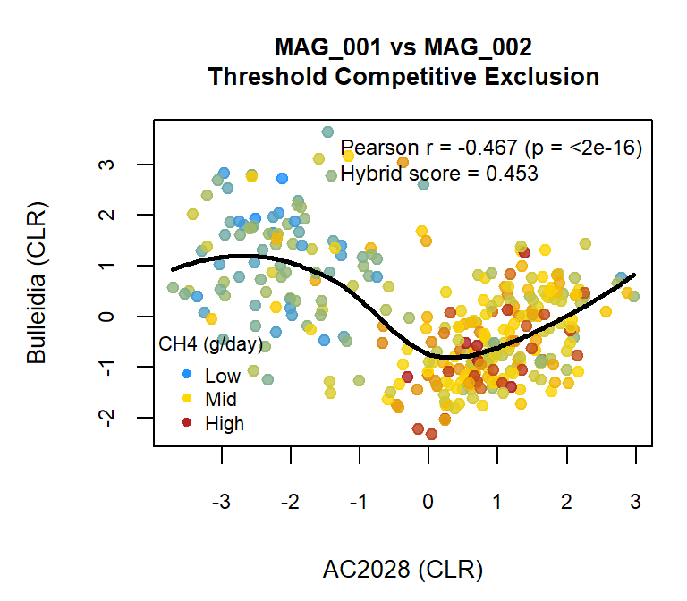

```r
# ---- Pair 1: Threshold competitive exclusion (Bulleidia vs AC2028) ----
x1 <- net_input[, "MAG_002"]
y1 <- net_input[, "MAG_001"]
ct1 <- cor.test(x1, y1)
hs1 <- get_hybrid_score(result$all_edges_unfiltered, "MAG_001", "MAG_002")

par(mar = c(4.5, 4.5, 3.5, 1))
plot(x1, y1,
     xlab = "AC2028 (CLR)",
     ylab = "Bulleidia (CLR)",
     main = "MAG_001 vs MAG_002\nThreshold Competitive Exclusion",
     cex.main = 0.85, cex.axis = 0.75, cex.lab = 0.85,
     pch = 19, col = adjustcolor(ch4_cols, 0.8), cex = 0.9)
lo <- loess(y1 ~ x1, span = 0.75)
ox <- order(x1)
lines(x1[ox], predict(lo)[ox], col = "black", lwd = 2.5)

legend("topright", bty = "n", cex = 0.75,
       legend = c(
         paste0("Pearson r = ", round(ct1$estimate, 3),
                " (p = ", format.pval(ct1$p.value, digits = 2), ")"),
         paste0("Hybrid score = ", hs1)
       ))
legend("bottomleft", bty = "n", cex = 0.7, title = "CH4 (g/day)",
       legend = c("Low", "Mid", "High"),
       pch = 19, col = c("dodgerblue", "gold", "firebrick"))
```

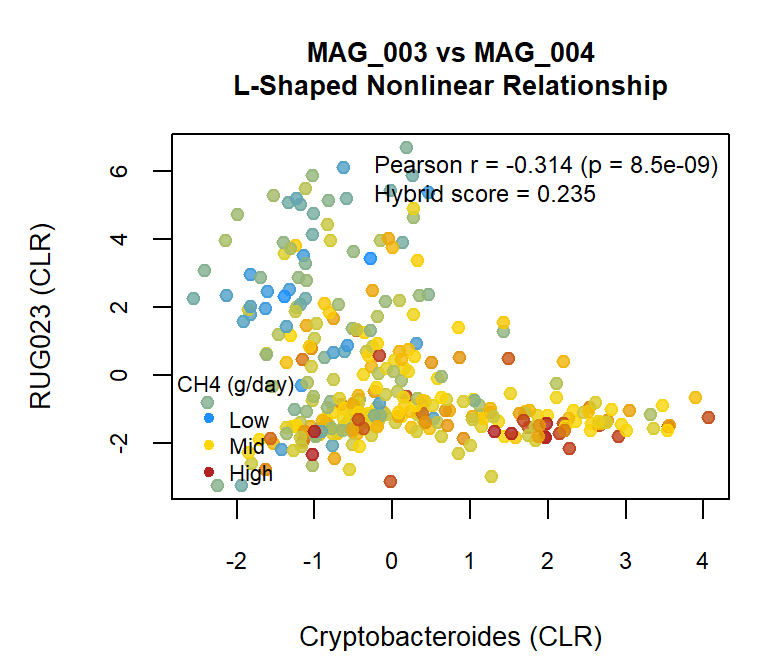

```r
# ---- Pair 2: L-shaped relationship (RUG023 vs Cryptobacteroides) ----
x2 <- net_input[, "MAG_004"]
y2 <- net_input[, "MAG_003"]
ct2 <- cor.test(x2, y2)
hs2 <- get_hybrid_score(result$all_edges_unfiltered, "MAG_003", "MAG_004")

par(mar = c(4.5, 4.5, 3.5, 1))
plot(x2, y2,
     xlab = "Cryptobacteroides (CLR)",
     ylab = "RUG023 (CLR)",
     main = "MAG_003 vs MAG_004\nL-Shaped Nonlinear Relationship",
     cex.main = 0.85, cex.axis = 0.75, cex.lab = 0.85,
     pch = 19, col = adjustcolor(ch4_cols, 0.8), cex = 0.9)

legend("topright", bty = "n", cex = 0.75,
       legend = c(
         paste0("Pearson r = ", round(ct2$estimate, 3),
                " (p = ", format.pval(ct2$p.value, digits = 2), ")"),
         paste0("Hybrid score = ", hs2)
       ))
legend("bottomleft", bty = "n", cex = 0.7, title = "CH4 (g/day)",
       legend = c("Low", "Mid", "High"),
       pch = 19, col = c("dodgerblue", "gold", "firebrick"))
```

# 9 Re-thresholding

`threshold_edges()` re-thresholds the full scored edge list without re-running the bootstrap. This is useful for exploring different stringency levels.

| Parameter | Default | Suggested | Description |
| --- | --- | --- | --- |
| `method` | “quantile” | “quantile” or “top_n” | Thresholding strategy |
| `value` | 0.8 | 0.7 to 0.9 for quantile; 10 to 50 for top_n | Cutoff value |

```r
strict <- threshold_edges(result$all_edges, method = "quantile", value = 0.8)
cat("Edges at 80th percentile:", nrow(strict), "\n")
```

```
#> Edges at 80th percentile: 458
```

# 10 Score Distribution

The S3 `plot()` method shows the hybrid score distribution with the threshold cutoff marked.

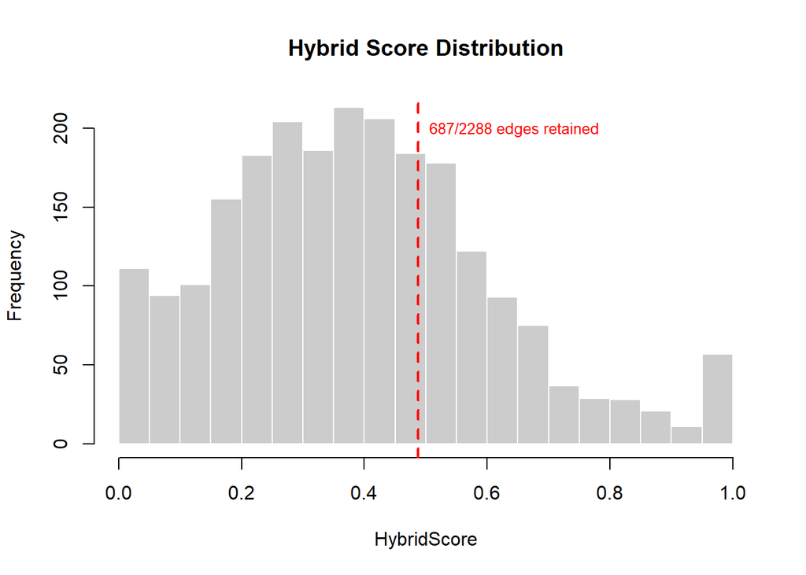

```r
plot(result)
```

# 11 Taxonomy Annotation

Merge taxonomy onto edges to see which lineages are co-abundant.

```r
edges <- result$edges

# Add source taxonomy
edges <- merge(edges, fancy_tiny_taxonomy[, c("Genus", "Phyla")],
               by.x = "source", by.y = "row.names", all.x = TRUE)
names(edges)[names(edges) == "Genus"] <- "source_Genus"
names(edges)[names(edges) == "Phyla"] <- "source_Phyla"

# Add target taxonomy
edges <- merge(edges, fancy_tiny_taxonomy[, c("Genus", "Phyla")],
               by.x = "target", by.y = "row.names", all.x = TRUE)
names(edges)[names(edges) == "Genus"] <- "target_Genus"
names(edges)[names(edges) == "Phyla"] <- "target_Phyla"

head(edges[order(-edges$HybridScore),
     c("source_Genus", "target_Genus", "source_Phyla", "target_Phyla",
       "HybridScore")], 15)
```

```
#>         source_Genus     target_Genus source_Phyla target_Phyla HybridScore
#> 36           CAG-791          CAG-791    Bacillota    Bacillota           1
#> 46           CAG-791          CAG-791    Bacillota    Bacillota           1
#> 52           CAG-791          CAG-791    Bacillota    Bacillota           1
#> 53           CAG-791          CAG-791    Bacillota    Bacillota           1
#> 61           CAG-791          CAG-791    Bacillota    Bacillota           1
#> 65           CAG-791          CAG-791    Bacillota    Bacillota           1
#> 68           CAG-791          CAG-791    Bacillota    Bacillota           1
#> 69           CAG-791          CAG-791    Bacillota    Bacillota           1
#> 73           CAG-791          CAG-791    Bacillota    Bacillota           1
#> 74           CAG-791          CAG-791    Bacillota    Bacillota           1
#> 75           CAG-791          CAG-791    Bacillota    Bacillota           1
#> 79           CAG-791          CAG-791    Bacillota    Bacillota           1
#> 81           CAG-791          CAG-791    Bacillota    Bacillota           1
#> 92  Succiniclasticum Succiniclasticum    Bacillota    Bacillota           1
#> 120          CAG-791           RUG842    Bacillota    Bacillota           1
```

# 12 Network Visualization

If `igraph` is installed, `plot_network()` draws the co-abundance network with nodes coloured by phylum and edges weighted by HybridScore. Communities are detected using modularity-based clustering (analogous to GLay in Cytoscape). Shaded regions group MAGs that co-occur more frequently with each other than with MAGs outside their cluster.

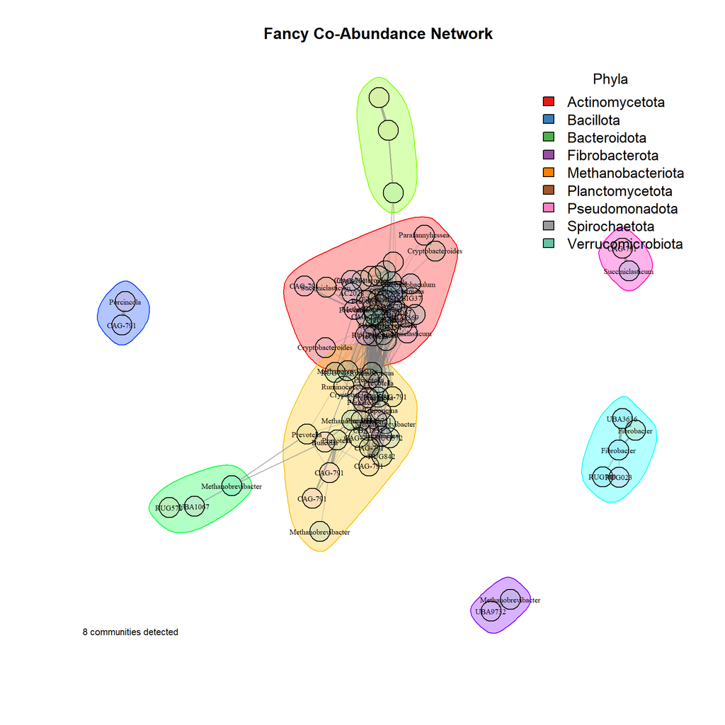

```r
plot_network(result, fancy_tiny_taxonomy, community = TRUE)
```

# 13 Exporting for Cytoscape

`export_cytoscape()` writes node and edge tables as tab-separated files that Cytoscape can import directly.

| Parameter | Default | Description |
| --- | --- | --- |
| `fancy_result` |  | Object of class `"fancy"` |
| `taxonomy` |  | Data.frame with MAG IDs as rownames, must have `Phyla` column |
| `file_prefix` | “fancy_network” | Path prefix for output TSV files |
| `edges` | “thresholded” | Which edges: `"thresholded"` or `"all"` |

```r
cyto <- export_cytoscape(
  result,
  fancy_tiny_taxonomy,
  file_prefix = tempfile("fancy")
)
```

The returned list contains the same data.frames that were written to disk:

```r
head(cyto$edges)
```

```
#>    source  target HybridScore
#> 1 MAG_002 MAG_085           1
#> 2 MAG_002 MAG_090           1
#> 3 MAG_007 MAG_018           1
#> 4 MAG_007 MAG_023           1
#> 5 MAG_007 MAG_027           1
#> 6 MAG_008 MAG_033           1
```

```r
head(cyto$nodes)
```

```
#>        id   Domain          Phyla          Class              Order              Family             Genus           Species   Color
#> 1 MAG_001 Bacteria      Bacillota        Bacilli Erysipelotrichales Erysipelotrichaceae         Bulleidia                sp #377EB8
#> 2 MAG_002 Bacteria      Bacillota     Clostridia     Lachnospirales     Lachnospiraceae            AC2028            AC2028 #377EB8
#> 3 MAG_003 Bacteria  Spirochaetota   Spirochaetia   Sphaerochaetales   Sphaerochaetaceae            RUG023            RUG023 #999999
#> 4 MAG_004 Bacteria   Bacteroidota    Bacteroidia      Bacteroidales              UBA932 Cryptobacteroides Cryptobacteroides #4DAF4A
#> 5 MAG_005 Bacteria Actinomycetota Coriobacteriia   Coriobacteriales     Eggerthellaceae           UBA9715           UBA9715 #E41A1C
#> 6 MAG_006 Bacteria      Bacillota  Negativicutes  Acidaminococcales  Acidaminococcaceae  Succiniclasticum  Succiniclasticum #377EB8
```

To import into Cytoscape:

1. **File > Import > Network from File**: select the `*_edges.tsv` file. Map `source` to Source Node, `target` to Target Node, and `HybridScore` to an edge attribute.
2. **File > Import > Table from File**: select the `*_nodes.tsv` file. Map the `id` column to the node key column.
3. Use the `Color` column in the node table to set node fill colour by mapping it as a passthrough in the Style panel.
4. **Apps > Community Detection (GLay)** to run GLay community clustering on the network.

# 14 Saving Results

To save all pipeline and intermediate objects for later use without re-running the bootstrap:

```r
save(result, net_input,
     fancy_tiny_clr, fancy_tiny_counts, fancy_tiny_coverage,
     fancy_tiny_taxonomy, fancy_tiny_metadata,
     all_scored, show_pairs, diag_df, edges, top5, strict,
     file = "vignette_objects.RData")
```